# Datanauts: Outgassing DB Data

Katherine Simeon

August 2018

## A Quick Preface

I am excited to be part of the Fall 2018 Class of [NASA Datanauts](https://open.nasa.gov/explore/datanauts/)! I’ll be using this repo to keep track of my work for this program. I’m currently on **Track 1: Intro to Coding** where I am creating a github project page to diplay live data.

## Outgassing DB Data

The data we are using is from NASA’s open data portal and is a compilation of [outgassing data](https://data.nasa.gov/Applied-Science/Outgassing-Db/r588-f7pr) of materials, intended for spacecraft use. The data were obtained at the Goddard Space Flight Center (GSFC).

To be honest, I have no idea what outgassing is and what this data means. I found this [blog post](http://mwexpert.typepad.com/rog_blog/2010/11/what-is-outgassing-and-when-does-it-matter.html) to be helpful in explaining the basic concepts in lay language. In short:

> Outgassing is a concern for any electronic equipment intended for use in high-vacuum environments. It refers to the release of gas trapped within a solid, such as a high-frequency circuit-board material… In space-based equipment, released gas can condense on such materials as camera lenses, rendering them inoperative.

Some variables we see in the data set:

- Total mass loss (TML)
- Collected volatile condensable materials (CVCM)
- Water vapor recovered (WVR)

Our assignment was the following: To tweak the site files to pull Outgassing data from data.nasa.gov via an API onto your site.

This a screenshot of how mine looked:

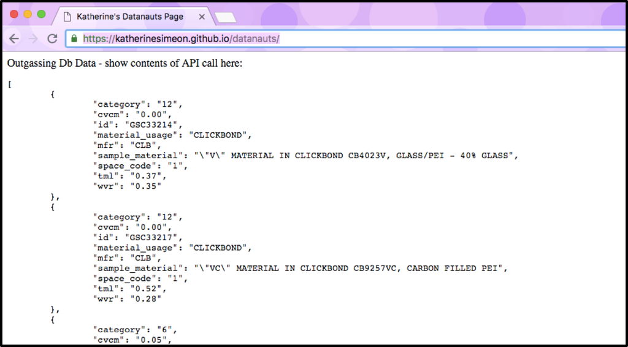

*My static site displaying data*

Success! But, this presentation isn’t super user-friendly.

I figured this would be a good opportunity to play around with this data in R. In particular, I want to learn about working with `.json` files in R (I don’t use `.json` files generally so I’m excited to familiarize myself with this file format). Also, for now I am sorta avoiding using javascript (the code for the original exercise was `.js` which you can see in the [archives folder](https://github.com/katherinesimeon/datanauts/tree/master/Archive) of my Datanauts repo). Hopefully I can develop more javascript knowledge at a later time.

### Packages

Here are the packages I used (I am open to suggestions for other helpful tools!)

```r
library(rjson) # Working with .json files in R
library(DT) # We'll use this to make data readable (hopefully!)
```

### Loading our data

*(in the `setup` R chunk)*

```r
knitr::opts_chunk$set(echo = TRUE)
# Data table version
json_data <- fromJSON(file='https://data.nasa.gov/resource/gymh-eyc2.json')
```

### Creating a data frame

```r
# Unlist the fromJSON() output
json_unlisted <- lapply(json_data,
                        function(x) {
  x[sapply(x, is.null)] <- NA
  unlist(x)
})

# Combine our dissected parts of the json file and make it a dataframe
outgassing_df <- as.data.frame(do.call("cbind", json_unlisted))
# how big is our dataframe
dim(outgassing_df)
```

```
## [1]   10 1000
```

There are a lot of columns, so when I use `head()`, I’m only going to pull the first 6 columns:

```r
# View the first six rows and columns our dataframe
head(outgassing_df[,1:6])
```

```
##                                                                      V1
## category                                                             12
## cure                                                               0.00
## cvcm                                                           GSC33214
## id                                                            CLICKBOND
## material_usage                                                      CLB
## mfr            "V" MATERIAL IN CLICKBOND CB4023V, GLASS/PEI - 40% GLASS
##                                                                    V2
## category                                                           12
## cure                                                             0.00
## cvcm                                                         GSC33217
## id                                                          CLICKBOND
## material_usage                                                    CLB
## mfr            "VC" MATERIAL IN CLICKBOND CB9257VC, CARBON FILLED PEI
##                                                    V3              V4
## category                                            6              15
## cure                                             0.05            0.13
## cvcm                                         GSC32950        GSC34174
## id                                   BLANKET MATERIAL           ORING
## material_usage                                    SCH             PRS
## mfr            0.5 MIL KAPTON KEVLAR, SHELDAHL 177544 0667 BLACK EPDM
##                                 V5                                     V6
## category                        16                                      6
## cure                          0.08                                   0.03
## cvcm                      GSC33829                               GSC32947
## id                            TAPE                       BLANKET MATERIAL
## material_usage                 MMM                                    SCH
## mfr            1 INCH COPPER TAPE  1.6 MIL GBK NOMEX, SHELDAHL 177541-001
```

## Formatting our Data

### Transposing the data frame

Our dataframe has 1000 columns because of the way it was unlisted. The output of `fromJSON()` is a list.

Using the function `head()`, we see that each material in our dataset is notated as `[[number]]` and has multiple members (i.e. category, cvcm, id). So `[[1]]` has a value for `[[1]]$id` and etc.

```r
class(json_data)
```

```
## [1] "list"
```

```r
json_data[1:2] # See items 1 and 2 in list json_data
```

```
## [[1]]
## [[1]]$category
## [1] "12"
##
## [[1]]$cvcm
## [1] "0.00"
##
## [[1]]$id
## [1] "GSC33214"
##
## [[1]]$material_usage
## [1] "CLICKBOND"
##
## [[1]]$mfr
## [1] "CLB"
##
## [[1]]$sample_material
## [1] "\"V\" MATERIAL IN CLICKBOND CB4023V, GLASS/PEI - 40% GLASS"
##
## [[1]]$space_code
## [1] "1"
##
## [[1]]$tml
## [1] "0.37"
##
## [[1]]$wvr
## [1] "0.35"
##
##
## [[2]]
## [[2]]$category
## [1] "12"
##
## [[2]]$cvcm
## [1] "0.00"
##
## [[2]]$id
## [1] "GSC33217"
##
## [[2]]$material_usage
## [1] "CLICKBOND"
##
## [[2]]$mfr
## [1] "CLB"
##
## [[2]]$sample_material
## [1] "\"VC\" MATERIAL IN CLICKBOND CB9257VC, CARBON FILLED PEI"
##
## [[2]]$space_code
## [1] "1"
##
## [[2]]$tml
## [1] "0.52"
##
## [[2]]$wvr
## [1] "0.28"
```

We want to make each material its own list in a dataframe. So we applied `unlist()` on our list and then used `cbind()` to put these lists together in a data frame. We did this when creating our dataframe.

However, this resulted in each material in its own column. It’s more intuitive to have each material in its own row. So we can transpose with `t()`.

```r
head(t(outgassing_df))
```

```
##    category cure   cvcm       id                 material_usage
## V1 "12"     "0.00" "GSC33214" "CLICKBOND"        "CLB"
## V2 "12"     "0.00" "GSC33217" "CLICKBOND"        "CLB"
## V3 "6"      "0.05" "GSC32950" "BLANKET MATERIAL" "SCH"
## V4 "15"     "0.13" "GSC34174" "ORING"            "PRS"
## V5 "16"     "0.08" "GSC33829" "TAPE"             "MMM"
## V6 "6"      "0.03" "GSC32947" "BLANKET MATERIAL" "SCH"
##    mfr
## V1 "\"V\" MATERIAL IN CLICKBOND CB4023V, GLASS/PEI - 40% GLASS"
## V2 "\"VC\" MATERIAL IN CLICKBOND CB9257VC, CARBON FILLED PEI"
## V3 "0.5 MIL KAPTON KEVLAR, SHELDAHL 177544"
## V4 "0667 BLACK EPDM"
## V5 "1 INCH COPPER TAPE "
## V6 "1.6 MIL GBK NOMEX, SHELDAHL 177541-001"
##    sample_material space_code tml    wvr
## V1 "1"             "0.37"     "0.35" "12"
## V2 "1"             "0.52"     "0.28" "12"
## V3 "1"             "2.48"     "1.97" "6"
## V4 "1"             "0.65"     "0.07" "15"
## V5 "1"             "0.24"     "0.01" "16"
## V6 "1"             "1.81"     "1.76" "6"
```

### Creating a data table

Now we can put our data frame in a table for perusal.

```r
# Using the DT package:
datatable(t(outgassing_df),options = list(searching=TRUE,pageLength=6))
```

|  | category | cure | cvcm | id | material_usage | mfr | sample_material | space_code | tml | wvr |
| --- | --- | --- | --- | --- | --- | --- | --- | --- | --- | --- |
| V1 | 12 | 0.00 | GSC33214 | CLICKBOND | CLB | "V" MATERIAL IN CLICKBOND CB4023V, GLASS/PEI - 40% GLASS | 1 | 0.37 | 0.35 | 12 |
| V2 | 12 | 0.00 | GSC33217 | CLICKBOND | CLB | "VC" MATERIAL IN CLICKBOND CB9257VC, CARBON FILLED PEI | 1 | 0.52 | 0.28 | 12 |
| V3 | 6 | 0.05 | GSC32950 | BLANKET MATERIAL | SCH | 0.5 MIL KAPTON KEVLAR, SHELDAHL 177544 | 1 | 2.48 | 1.97 | 6 |
| V4 | 15 | 0.13 | GSC34174 | ORING | PRS | 0667 BLACK EPDM | 1 | 0.65 | 0.07 | 15 |
| V5 | 16 | 0.08 | GSC33829 | TAPE | MMM | 1 INCH COPPER TAPE | 1 | 0.24 | 0.01 | 16 |
| V6 | 6 | 0.03 | GSC32947 | BLANKET MATERIAL | SCH | 1.6 MIL GBK NOMEX, SHELDAHL 177541-001 | 1 | 1.81 | 1.76 | 6 |
| V7 | 6 | 0.01 | GSC33397 | COND BLANKET FILM | DUN | 100 DUN-LAM, GE COATED BLACK KAPTON XC | 1 | 0.89 | 0.67 | 6 |
| V8 | 15 | 4H | 0.07 | GSC34036 | O-RING | APR | 10SL7AP APPLE RUBBER 70 DURIMETER PHENYL SILICONE O-RING | 1 | 0.26 | 0.05 |
| V9 | 15 | 4H | 0.01 | GSC34039 | O-RING | APR | 10SL7AP APPLE RUBBER 70 DURIMETER PHENYL SILICONE O-RING | 2 | 0.09 | 0.05 |
| V10 | 16 | 0.09 | GSC32728 | TAPE | MMM | 1170 ALUMINUM FOIL EMI SHIELDING TAPE | 1 | 0.30 | 0.02 | 16 |

[output cut: 990 more lines]

*Addendum: Yay! It worked!*

## Future Directions

Overall, this was a fun, quick exercise to start exploring NASA data. Some goals/follow-up tasks that I will keep in mind:

**Learn more about the concepts related to NASA data** - During my Datanaut experience, I will try to read up on outgassing, comets, and other space concepts that are related to the data we are working with. I welcome any reading/resource suggestions!

**Go from RMarkdown to Shiny** - I used R-Markdown to write this explanation and work with the data in R. This is a perfect scenario for a shiny app (in fact, the [source page](https://data.nasa.gov/Applied-Science/Outgassing-Db/r588-f7pr) for the outgassing data has a “Create Visualization” button). This would be a great follow up project to actually apply what I’ve been learning about in Shiny.

**Put everything I am learning about in context** - The first track involved getting started on github, making an API, and creating a github page (2 of these 3 I’d already done from my work in R-Ladies). [Making an API](https://nasadatanauts.github.io/alexbelloni/track1lesson2/index.html) was not difficult given the instructions provided and it was interesting to learn (I had never heard of Firebase); however, I still don’t understand why we did it during the first track in Datanauts. During this learning process, I want to make sure I take the time to think/reflect on why we are learning specific techniques and topics. I also want to take a hypothesis-driven approach when working with these data sets.

That’s all for now! I hope to keep writing about this process as Datanauts continues!